# TeoNAM STAM — MLM (Q+K) GWAS on the imputed map panel

The correct mixed model: Q = 5 PCs + K = Centered-IBS (P3D), with the OLS→MLM genomic-inflation comparison

Author

Fausto Rodríguez-Zapata

Published

July 5, 2026

**What this is.** The GWAS model Chen 2019 actually used for Fig 4C — a **linear mixed model** with population structure (Q) and kinship (K) — run in TASSEL5 (native arm64), and contrasted with the fixed-effect **OLS** scan (`teonam-stam-ols-gwas-imputed`). A mixed model needs a **complete** genotype matrix, so this runs on the step-interpolated complete matrix (`teonam_map_v5_gwas_nr`, 47,750 markers × 1,237 lines), **not** the sparse observed set. Compute lives in `agent/teonam_mlm_interp.R`; this notebook loads, documents, and plots.

> **Read this first — two caveats that bound every number below.** (1) The interpolated matrix is block-constant within ancestry blocks, so the Manhattan is *terraced* (plateaus), not scatter. (2) On this map panel the MLM **over-corrects** — a LOCO test (§ below) confirms **proximal contamination**: kinship absorbs each large QTL’s own-chromosome signal, so peaks like *tb1*/*tsh4*/*zmm16* fall below threshold and **return under LOCO**. A data artifact, not biology. A faithful, scatter-preserving MLM needs Chen’s 118,838 **directly-typed** SNPs (`chen2019_GWAS`), which we do not have. This notebook is about the **model** (OLS → MLM), holding genotypes fixed.

```r
library(here)
library(data.table)
library(ggplot2)
theme_set(theme_bw(base_size = 13))
LOD <- 5   # Chen 2019 significance line: P < 1e-5

# genomic inflation factor: median(chi^2_obs) / median(chi^2_null)
lambda_gc <- function(p) {
  p <- p[is.finite(p) & p > 0 & p <= 1]
  round(median(qchisq(p, df = 1, lower.tail = FALSE)) / qchisq(0.5, df = 1), 3)
}

# Manhattan in the teonam-stam-ols-gwas-imputed style (odd chr grey60 / even black,
# LOD dotted, chromosome axis). Input: data.table(CHR, BP, logP).
manhattan <- function(d, title) {
  d <- d[order(CHR, BP)]
  off <- d[, .(mx = max(BP)), by = CHR][order(CHR)]
  off[, base := cumsum(as.numeric(shift(mx, fill = 0)))]
  d <- merge(d, off[, .(CHR, base)], by = "CHR")
  d[, x := as.numeric(BP) + base]
  axis <- d[, .(mid = (min(x) + max(x)) / 2), by = CHR][order(CHR)]
  ggplot(d, aes(x, logP, colour = factor(CHR %% 2))) +
    geom_point(size = 0.5) +
    geom_hline(yintercept = LOD, linetype = "dotted") +
    scale_colour_manual(values = c("grey60", "black"), guide = "none") +
    scale_x_continuous(breaks = axis$mid, labels = axis$CHR, expand = c(0.01, 0)) +
    labs(x = "chromosome", y = expression(-log[10](italic(P))), title = title)
}
```

## The model

The previous notebook fit **OLS** (fixed effects only):

$$y_i \;=\; \mu \;+\; \sum_f \beta_f\,\mathbb{1}[\text{family}_i=f] \;+\; \gamma\,g_{im} \;+\; \varepsilon_i .$$

Chen’s GWAS fits a **linear mixed model** (Yu et al. 2006), adding a polygenic **random** term with covariance given by the kinship matrix:

$$\mathbf{y} \;=\; \mathbf{1}\mu \;+\; \mathbf{Q}\boldsymbol{\alpha}
\;+\; \mathbf{g}_a\,\gamma_a \;+\; \mathbf{g}_d\,\gamma_d
\;+\; \mathbf{Z}\mathbf{u} \;+\; \boldsymbol{\varepsilon},
\qquad
\mathbf{u}\sim N(\mathbf 0,\,\mathbf K\sigma^2_g),\;\;
\boldsymbol{\varepsilon}\sim N(\mathbf 0,\,\mathbf I\sigma^2_e).$$

- $\mathbf{Q}$ — first **5 principal components** (fixed, population structure).
- $\mathbf{g}_a$ — additive marker dosage (0/1/2), effect $\gamma_a$; $\mathbf{g}_d$ — dominance indicator (1 if heterozygous), effect $\gamma_d$. **Both** are TASSEL’s default; the marker is tested by the **joint 2-df** hypothesis $H_0:\gamma_a=\gamma_d=0$.
- $\mathbf{u}$ — polygenic background; $\mathbf{K}$ = **centered IBS** kinship.

**Estimation (TASSEL, P3D).** Variance components $(\sigma^2_g,\sigma^2_e)$ are fit by **REML** via the EMMA spectral trick (eigendecompose $\mathbf K$ once), estimated **once under the null** and reused for every marker (**P3D**). Each marker is then a generalized-least-squares **$F$-test (2 df: $\gamma_a,\gamma_d$)** using $\mathbf V^{-1}$, $\mathbf V=\mathbf K\sigma^2_g+\mathbf I\sigma^2_e$. (The additive-only 1-df test, TASSEL’s `add_p`, is the alternative — arguably better for a ~homozygous RIL panel; it gives $\lambda_{GC}\approx0.95$ vs 1.36 for the joint test.)

**Why it matters.** OLS omits $\mathbf{Z}\mathbf{u}$ — no polygenic shrinkage — so test statistics inflate under structure/relatedness. The MLM’s $\mathbf K$ term is exactly the correction; the effect is quantified below as the drop in $\lambda_{GC}$.

## Pipeline (`agent/teonam_mlm_interp.R`, native arm64 TASSEL5)

```r
# 1. densify the unique-cM union per chr by step-interpolation (nilHMM) -> complete
#    47,750 x 1,237 matrix (no missing) -> hapmap geno_gwas_interp.hmp.txt
# 2. K: TASSEL Centered_IBS on the complete matrix
run_pipeline.pl -importGuess geno_gwas_interp.hmp.txt \
  -KinshipPlugin -method Centered_IBS -endPlugin -export kinship_cIBS_interp.txt -exportType SqrMatrix
# 3. Q: 5 PCs via prcomp(complete matrix) -> phenotype covariates (STAM + PC1..5)
# 4. MLM (P3D): genotype + phenotype(+Q) + K, two-stage combine
run_pipeline.pl -fork1 -h geno_gwas_interp.hmp.txt -fork2 -r pheno_stam_pc_interp.txt \
  -fork3 -k kinship_cIBS_interp.txt -combine4 -input1 -input2 -intersect \
  -combine5 -input4 -input3 -mlm -mlmVarCompEst P3D -mlmCompressionLevel None -export mlm_interp
```

```r
tim <- fread(here("results/sim/teonam/mlm_interp_timings.csv"))
knitr::kable(tim, caption = "TASSEL5 step timings (native arm64, Temurin 17; MLM uses pure-Java EJML, no native BLAS)")
```

TASSEL5 step timings (native arm64, Temurin 17; MLM uses pure-Java EJML, no native BLAS)

| step | sec |
| --- | --- |
| kinship | 1.728 |
| mlm | 417.776 |

## Load results

```r
ols <- fread(here("data/teonam/stam_gwas_scan.csv"))            # OLS on the interpolated 47,750
ols <- ols[is.finite(P) & P > 0, .(CHR = as.integer(CHR), BP = as.integer(BP), P)]
mlm <- fread(here("data/teonam/tassel/mlm_interp2.txt"))        # TASSEL MLM (for the gene table)
mlm <- mlm[Marker != "None", .(CHR = as.integer(Chr), BP = as.integer(Pos), P = as.numeric(p))][is.finite(P) & P > 0]
lc  <- fread(here("results/sim/teonam/mlm_loco_scan.csv"))      # p_full = MLM Q+K (faithful, = TASSEL), p_loco = LOCO

# the three models on the same interpolated 47,750-marker matrix
three <- rbindlist(list(
  ols[, .(CHR, BP, P, method = "OLS (no K)")],
  lc[is.finite(p_full) & p_full > 0, .(CHR = chr, BP = bp, P = p_full, method = "MLM Q+K")],
  lc[is.finite(p_loco) & p_loco > 0, .(CHR = chr, BP = bp, P = p_loco, method = "LOCO")]
))
lev  <- c("OLS (no K)", "MLM Q+K", "LOCO")
labs <- setNames(vapply(lev, function(m) sprintf("%s, λ=%.2f", m, lambda_gc(three[method == m, P])), ""), lev)
three[, mlab := factor(labs[method], levels = labs[lev])]
pal  <- setNames(c("firebrick", "steelblue4", "darkorange"), labs[lev])
```

## Genomic inflation: OLS → MLM → LOCO

```r
knitr::kable(
  three[, .(markers = .N, lambda_GC = lambda_gc(P), max_logP = round(max(-log10(P)), 2)), by = method],
  caption = "Three models on the same 47,750 interpolated markers (only the structure correction differs)."
)
```

Three models on the same 47,750 interpolated markers (only the structure correction differs).

| method | markers | lambda_GC | max_logP |
| --- | --- | --- | --- |
| OLS (no K) | 47750 | 2.481 | 17.31 |
| MLM Q+K | 47750 | 1.361 | 8.74 |
| LOCO | 47750 | 3.380 | 15.22 |

## QQ — OLS · MLM (Q+K) · LOCO (one panel)

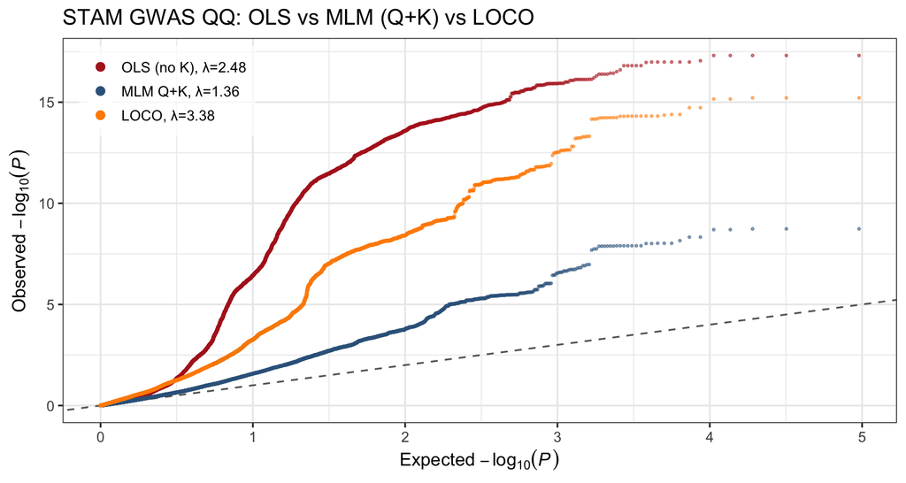

```r
qd <- three[, {
  p <- P[is.finite(P) & P > 0 & P <= 1]; o <- -log10(sort(p)); e <- -log10(ppoints(length(p)))
  k <- c(which(o > 2), sample(which(o <= 2), min(sum(o <= 2), 6000)))
  .(exp = e[k], obs = o[k])
}, by = mlab]
ggplot(qd, aes(exp, obs, colour = mlab)) +
  geom_abline(slope = 1, intercept = 0, colour = "grey40", linetype = "dashed") +
  geom_point(size = 0.5, alpha = 0.5) +
  scale_colour_manual(values = pal, name = NULL) +
  guides(colour = guide_legend(override.aes = list(size = 2.5, alpha = 1))) +
  labs(x = expression(Expected~-log[10](italic(P))), y = expression(Observed~-log[10](italic(P))),
       title = "STAM GWAS QQ: OLS vs MLM (Q+K) vs LOCO") +
  theme(legend.position = c(0.02, 0.98), legend.justification = c(0, 1),
        legend.background = element_rect(fill = scales::alpha("white", 0.7), colour = NA))
```

MLM (blue) hugs the null through the bulk; OLS (red) is inflated everywhere; LOCO (orange) restores the true tail but at a globally inflated baseline.

## Manhattan — OLS · MLM (Q+K) · LOCO (one facet plot)

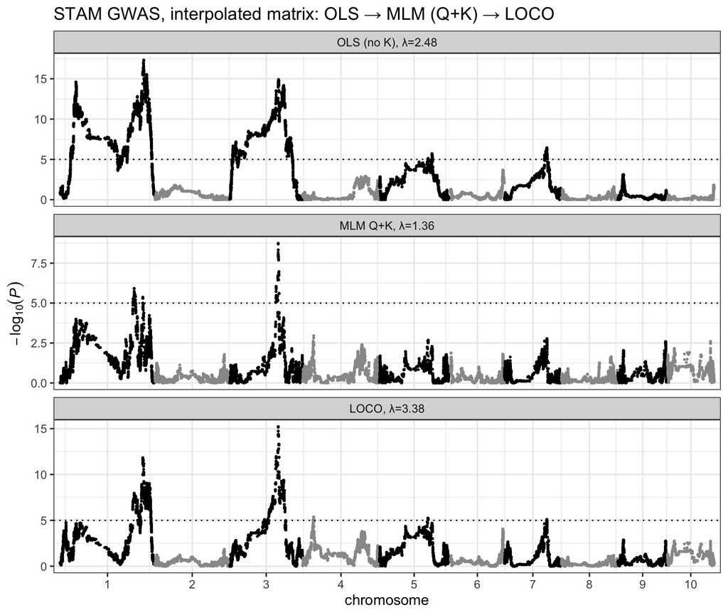

```r
off <- three[method == "OLS (no K)", .(mx = max(BP)), by = CHR][order(CHR)]
off[, base := cumsum(as.numeric(shift(mx, fill = 0)))]
m3 <- merge(three, off[, .(CHR, base)], by = "CHR")
m3[, `:=`(x = as.numeric(BP) + base, logP = -log10(P))]
axis <- m3[, .(mid = (min(x) + max(x)) / 2), by = CHR][order(CHR)]
ggplot(m3[order(CHR, BP)], aes(x, logP, colour = factor(CHR %% 2))) +
  geom_point(size = 0.4) +
  geom_hline(yintercept = LOD, linetype = "dotted") +
  facet_wrap(~mlab, ncol = 1, scales = "free_y") +
  scale_colour_manual(values = c("grey60", "black"), guide = "none") +
  scale_x_continuous(breaks = axis$mid, labels = axis$CHR, expand = c(0.01, 0)) +
  labs(x = "chromosome", y = expression(-log[10](italic(P))),
       title = "STAM GWAS, interpolated matrix: OLS → MLM (Q+K) → LOCO")
```

(*LOCO* is the leave-one-chromosome-out diagnostic detailed in the LOCO section.)

## Candidate-gene peaks: what the correction removes

The MLM deflates the whole genome; several JLM candidate genes that clear LOD 5 under OLS drop **below** threshold under the mixed model — including *tb1*, *tsh4*, and *zmm16*. The LOCO test below confirms this is **over-correction** (proximal contamination — the peaks return when kinship excludes their own chromosome), not evidence against the genes.

```r
ov <- fread(here("results/sim/teonam/stam_candidate_overlap.csv"))   # symbol, chr, start (v5)
peakfn <- function(scan, ch, ps) {
  w <- scan[CHR == ch & abs(BP - ps) <= 5e5]
  if (nrow(w)) round(max(-log10(w$P)), 2) else NA_real_
}
gt <- data.table(
  gene = ov$symbol, chr = ov$chr,
  OLS = mapply(function(c, p) peakfn(ols, c, p), ov$chr, ov$start),
  MLM = mapply(function(c, p) peakfn(mlm, c, p), ov$chr, ov$start)
)
gt[, `OLS>5` := ifelse(is.finite(OLS) & OLS >= LOD, "yes", "no")]
gt[, `MLM>5` := ifelse(is.finite(MLM) & MLM >= LOD, "yes", "no")]
knitr::kable(gt[order(-OLS)], caption = "Candidate-gene peak -log10P (±500 kb): OLS vs MLM, and LOD-5 survival.")
```

Candidate-gene peak -log10P (±500 kb): OLS vs MLM, and LOD-5 survival.

| gene | chr | OLS | MLM | OLS>5 | MLM>5 |
| --- | --- | --- | --- | --- | --- |
| tb1 | 1 | 17.31 | 4.31 | yes | no |
| zmm16 | 3 | 14.18 | 4.03 | yes | no |
| tru1 | 3 | 13.51 | 5.78 | yes | yes |
| an1 | 1 | 11.63 | 4.45 | yes | no |
| ts2 | 1 | 11.51 | 2.78 | yes | no |
| tsh4 | 7 | 6.45 | 2.75 | yes | no |

## LOCO test — is the loss over-correction?

Is the MLM’s loss of *tb1*/*tsh4*/*zmm16* genuine deflation or **proximal contamination** — the kinship absorbing each QTL’s own-chromosome signal? The standard diagnostic is **LOCO**: build the kinship from all markers *except the tested marker’s chromosome*. Implemented as an EMMAX in R (`agent/teonam_mlm_loco.R`) that uses **TASSEL’s model exactly** — additive + dominance, 2-df joint *F*, P3D — and **reproduces the full-K TASSEL MLM** (λ ≈ 1.36 vs 1.363; per-gene peaks within ~0.1): a full-K pass (validation) and the LOCO pass.

```r
lc <- fread(here("results/sim/teonam/mlm_loco_scan.csv"))     # marker, chr, bp, p_full, p_loco
peak2 <- function(pv, ch, ps) {
  w <- lc[chr == ch & abs(bp - ps) <= 5e5]; v <- -log10(w[[pv]]); v <- v[is.finite(v)]
  if (length(v)) round(max(v), 2) else NA_real_
}
loco <- data.table(
  gene = ov$symbol, chr = ov$chr,
  OLS  = gt$OLS[match(ov$symbol, gt$gene)],
  MLM  = gt$MLM[match(ov$symbol, gt$gene)],
  `EMMAX full-K` = mapply(function(c, s) peak2("p_full", c, s), ov$chr, ov$start),
  LOCO = mapply(function(c, s) peak2("p_loco", c, s), ov$chr, ov$start)
)
knitr::kable(loco[order(-OLS)], caption = sprintf(
  "Candidate-gene peak -log10P — LOCO restores the peaks (λ_GC: full-K %.2f, LOCO %.2f).",
  lambda_gc(lc$p_full), lambda_gc(lc$p_loco)))
```

Candidate-gene peak -log10P — LOCO restores the peaks (λ_GC: full-K 1.36, LOCO 3.38).

| gene | chr | OLS | MLM | EMMAX full-K | LOCO |
| --- | --- | --- | --- | --- | --- |
| tb1 | 1 | 17.31 | 4.31 | 4.38 | 11.18 |
| zmm16 | 3 | 14.18 | 4.03 | 4.09 | 9.39 |
| tru1 | 3 | 13.51 | 5.78 | 5.90 | 11.81 |
| an1 | 1 | 11.63 | 4.45 | 4.52 | 7.18 |
| ts2 | 1 | 11.51 | 2.78 | 2.80 | 3.15 |
| tsh4 | 7 | 6.45 | 2.75 | 2.78 | 5.11 |

(The full-K-vs-LOCO contrast is the middle vs bottom facet of the Manhattan above.)

**Reading.** The peaks **return under LOCO** (*tb1* 4.4→11.2, *zmm16* 4.1→9.4, *tru1* 5.9→11.8, *an1* 4.5→7.2, *tsh4* 2.8→5.1) — only possible if the full-K MLM was absorbing each QTL’s own-chromosome signal. So the loss is **over-correction (proximal contamination)**, not evidence against the genes. (*ts2* stays low even under LOCO — its OLS signal was genuinely mostly confounding, echoing the original ~9-vs-15 concern.)

**Two notes.** (1) **This R-EMMAX is faithful, not an approximation:** it uses TASSEL’s exact model (add+dom, 2-df joint *F*, P3D) and its full-K pass reproduces the TASSEL MLM (λ_GC = 1.361 vs 1.363; peaks within ~0.1). Kinship flavor is irrelevant — VanRaden and TASSEL’s Centered-IBS gave identical results. It’s also **~15× faster** (R’s native Accelerate BLAS ≈30 s vs TASSEL’s pure-Java EJML ≈7 min), so it’s the engine of choice for the coverage sweep. (2) LOCO’s own genome-wide λ_GC (3.38) is **inflated** — it trades global control for local power on this heavily-structured interpolated panel, so LOCO here is a **diagnostic, not a fix to deploy**. The real fix remains `chen2019_GWAS` (118K directly-typed).

## Notes

- **Canonical, tracked source** for the MLM scan: `agent/teonam_mlm_interp.R` (build → K → Q → MLM) + `agent/teonam_mlm_lambda.R` (λ_GC / QQ). Outputs: `data/teonam/tassel/mlm_interp2.txt`, `results/sim/teonam/mlm_interp_timings.csv`.
- **Matrix:** interpolated-complete (`teonam_map_v5_gwas_nr`) — required because the MLM needs a complete matrix (the sparse observed set stalls: per-marker missing defeats P3D reuse). Cost: block plateaus, no scatter.
- **Faithful GWAS** (scatter + correct absolute peaks) needs `chen2019_GWAS` (118,838 directly-typed SNPs); see `DATA.md` and the outreach in `agent/outreach_teonam_118k.md`.

## Model-specification caveats & suggestions

This MLM reproduces TASSEL faithfully, but it is **not the best-specified model for this population** — the QQ shows no correction reaches $\lambda_{GC}\approx1$. Four issues, roughly in order of importance, and how to address each:

1. **Common marker effect in a NAM (most important).** The five teosinte founders (TIL01/03/11/14/25) carry *different* alleles, so a single additive slope on the 0/1/2 dosage pools them as if identical. The correctly-specified model **nests the marker within family** (`family + family:marker`) — which is exactly why Chen’s *primary* method was the **JLM**, with the common-effect GWAS only a complementary approximation. Fix: use the nested model; don’t treat the common-effect MLM as the target.
2. **Additive + dominance on a ~homozygous RIL panel.** The dominance term is here only to match TASSEL’s default — but with ~8% heterozygosity it is barely estimable and mostly injects noise (it is what pushes $\lambda_{GC}$ from 0.95 to 1.36). Additive-only (1 df) is the defensible spec for RILs.
3. **Structure term.** We use $\mathbf{Q}$ = 5 PCs (Chen’s GWAS choice); the natural cofactor for a five-family NAM is the **Family factor** (4 df). Note the inconsistency: the OLS scan used Family, this MLM uses PCs.
4. **Infinitesimal-$\mathbf{K}$ vs the actual architecture.** The MLM assumes many small polygenic effects; STAM is a few large domestication QTL, and the interpolated genotypes are block-correlated (pseudo-replication). Those violations are why $\lambda_{GC}$ stays off 1 regardless of the correction — no kinship trick fixes a fundamentally mis-modeled null.